# Predict Power from VO2 with RER and GE

Author

Jem Arnold

Published

January 9, 2026

## Thread posted

> Common question I hear: "My VO2max is x and my current threshold power is y. Is it possible for me to reach an FTP of z?”

> It's surprisingly simple to predict power from VO2, and vice versa

> We just need reasonable estimates for RER substrate oxidation and metabolic efficiency 📊🧵/4 #rstats #datavis  
> [[ image or embed]](https://bsky.app/profile/did:plc:lnuu36x5tm3islrvwkxgsajn/post/3mbwyrtxync2t?ref_src=embed)

> — Jem Arnold ([@jemarnold.bsky.social](https://bsky.app/profile/did:plc:lnuu36x5tm3islrvwkxgsajn?ref_src=embed)) [8 January 2026 at 14:11](https://bsky.app/profile/did:plc:lnuu36x5tm3islrvwkxgsajn/post/3mbwyrtxync2t?ref_src=embed)

**Show setup code**

```r
library(tidyverse)
library(geomtextpath)
library(ggtext)
library(colorspace)
library(sysfonts)
library(showtext)

## use font & icons in ggplots
sysfonts::font_add_google(
    name = "Merriweather Sans",
    family = "Merriweather Sans"
)
sysfonts::font_add(
    family = "fa-brands",
    regular = r"(C:\Users\Jem\AppData\Local\Microsoft\Windows\Fonts\Font Awesome 7 Brands-Regular-400.otf)"
)
showtext::showtext_opts(dpi = 600)
showtext::showtext_auto()

## custom theme
theme_set(
    theme_bw(base_size = 12, base_family = "Merriweather Sans") +
        theme(
            plot.title = ggtext::element_textbox_simple(
                size = rel(1.2), lineheight = 1.1
            ),
            plot.subtitle = ggtext::element_textbox(
                colour = "grey35", face = "italic", hjust = 0,
                lineheight = 1.1, margin = margin(b = 4)
            ),
            plot.caption = ggtext::element_textbox(
                colour = "grey35", halign = 1
            ),
            panel.border = element_rect(linewidth = 0.8),
            axis.title = element_text(face = "bold"),
            panel.grid.major = element_blank(),
            panel.grid.minor = element_blank(),
            legend.position = "none"
        )
)

social_caption <- "<span style='font-family:fa-brands'>&#xf09b; &#xe671;</span> jemarnold"
```

## Post 1

Common question I hear: “*My VO2max is* x *and my current threshold power is* y*. Is it possible for me to reach an FTP of* z*?*”

It’s surprisingly simple to predict power from VO2, and vice versa

We just need reasonable estimates for RER substrate oxidation and metabolic efficiency 📊🧵/4 #rstats #datavis

**Show figure 1 code**

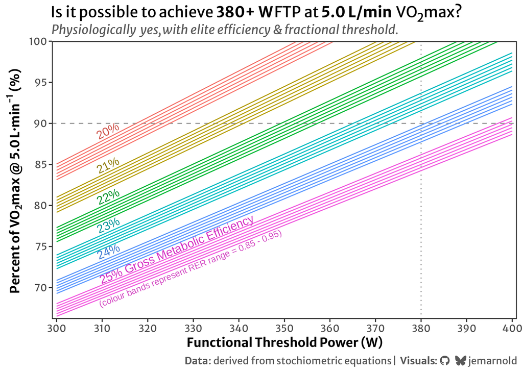

```r
VO2max_rel <- 71 ## ml/kg/min
weight <- 71 ## kg
VO2max <- VO2max_rel / 1000 * weight ## ≈ 5.0 L/min
power <- seq(300, 400, by = 10) ## W
RER <- seq(0.85, 0.95, 0.02) ## RER at threshold
GE <- 0.04824536 * log(power) - 0.05657161 ## % derived from Ettema & Lorås, 2009
GE <- round(seq(min(GE) - 0.025, max(GE) + 0.025, 0.01), 2)
GE <- seq(0.2, 0.25, 0.01) ## use pretty GE range anyway

df <- expand_grid(power, RER, GE) |>
    mutate(
        O2kJ = 4.83535 * RER + 16.88348, ## kJ/L derived from Péronnet & Massicotte, 1991
        VO2 = (power * 60 / 1000) / (GE * O2kJ), ## L/min
        VO2_rel = VO2 / VO2max, ## %
    )

ggplot(df, aes(x = power, y = VO2_rel, group = interaction(RER, GE), colour = factor(GE))) +
    labs( ## labs use markdown formatting with {ggtext}
        title = "Is it possible to achieve **380+ W** FTP at **5.0 L/min** VO<sub>2</sub>max?",
        subtitle = "Physiologically yes, with elite efficiency & fractional threshold.",
        caption = str_glue(
            "**Data**: derived from stochiometric equations | **Visuals**: {social_caption}"
        )
    ) +
    coord_cartesian(ylim = c(NA, 1)) +
    scale_x_continuous(
        name = "Functional Threshold Power (W)",
        breaks = power,
        expand = expansion(0.01)
    ) +
    scale_y_continuous(
        name = expression(bold(
            Percent~of~VO['2']*max~'@ 5.0'~L*'·'*min^'-1'~'(%)'
        )),
        label = scales::percent_format(suffix = ""),
        n.breaks = 6,
        expand = expansion(c(0.01, 0))
    ) +
    geom_hline(yintercept = 0.9, linetype = "dashed", colour = "grey60") +
    geom_vline(xintercept = 380, linetype = "dotted", colour = "grey60") +
    geom_line() +
    geomtextpath::geom_textline(
        data = ~ filter(.x, GE == rev(GE)[1L] & RER == 0.85),
        aes(
            label = str_glue("{round(GE*100)}% Gross Metabolic Efficiency"),
            colour = stage(factor(GE), after_scale = colorspace::darken(colour, 0.2))
        ),
        linewidth = 0, size = 4, hjust = 0.15, halign = "left", vjust = 0.2
    ) +
    geomtextpath::geom_textline(
        data = ~ filter(.x, GE != rev(GE)[1L] & RER == 0.85),
        aes(
            label = str_glue("{round(GE*100)}%"),
            colour = stage(factor(GE), after_scale = colorspace::darken(colour, 0.2))
        ),
        linewidth = 0, size = 4, hjust = 0.1, halign = "left", vjust = 0.1
    ) +
    geomtextpath::geom_textline(
        data = ~ filter(.x, GE == rev(GE)[1L] & RER == 0.95),
        aes(
            label = "(colour bands represent RER range = 0.85 - 0.95)",
            colour = stage(factor(GE), after_scale = colorspace::darken(colour, 0.15))
        ),
        linewidth = 0, size = 3.0, hjust = 0.15, halign = "left", vjust = 1.1
    )
```

Figure visualising the percent of a VO2max of 5.0 L/min required to produce functional threshold power (FTP) between 300 and 400 W, with isolines for gross metabolic efficiency (GE, %) from 20-25% and RER at each GE value between 0.85-0.95. The question was “is it possible to achieve an FTP of 380 W at a VO2max of 5.0 L/min (71 ml/kg/min at 71kg bodyweight)?” Based on these calculations, that would require somewhere around 24% GE and ~90% VO2max, which is just about physiologically plausible for an elite male cyclist… but would certainly take some work to achieve.

## Post 2

Reasonable estimates for gross metabolic efficiency (GE) for trained cyclists is 15-25%

GE logarithmically increases with power output, so higher fitness = higher power = higher GE

Prediction model: GE = 0.0482 * log(power) - 0.0566

90% prediction interval for individual values is around ± 2.5%

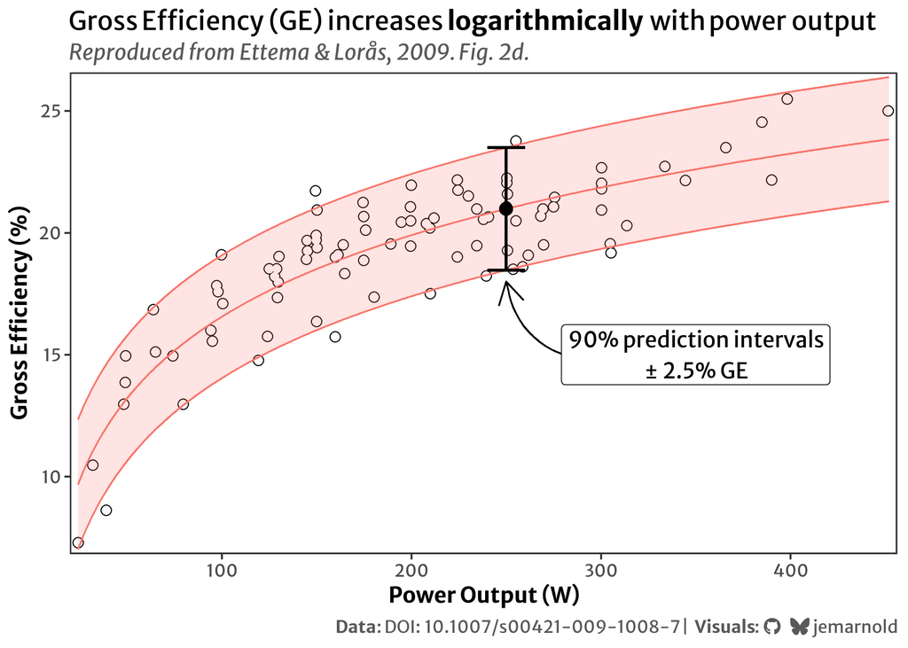

## Post 3

GE prediction model derived from data in Ettema & Lorås, 2009 (link in 📊Alt text)

GE is probably trainable, but veeery slowly

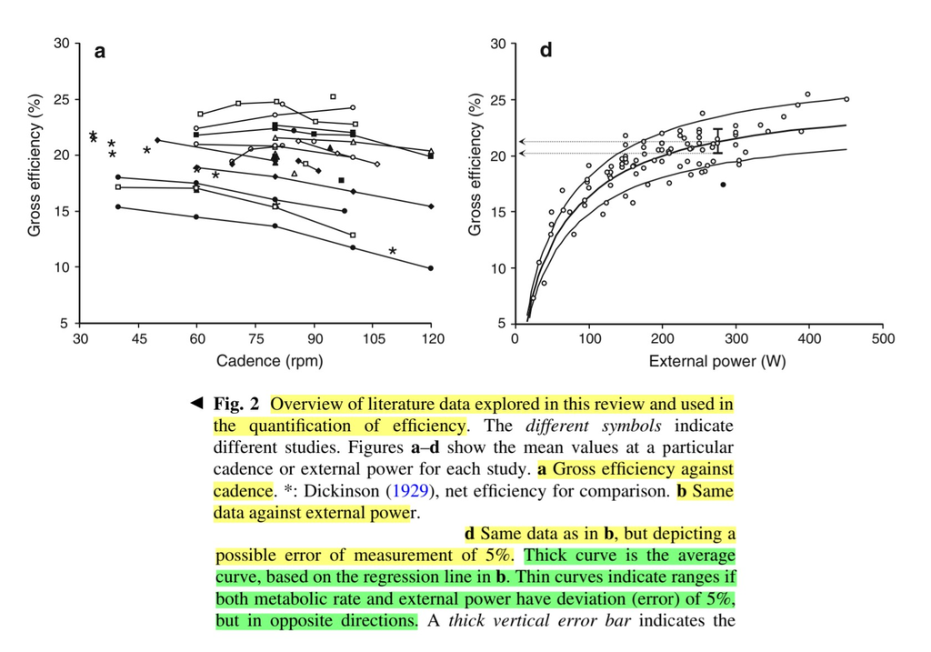

Figure reproduced from Ettema & Lorås, 2009. Efficiency in cycling: a review. Figure description reads: Fig. 2 Overview of literature data explored in this review and used in the quantification of efficiency. The different symbols indicate different studies. Figures a–d show the mean values at a particular cadence or external power for each study. a Gross efficiency against cadence. b Same data against external power… d Same data as in b, but depicting a possible error of measurement of 5%. Thick curve is the average curve, based on the regression line in b. Thin curves indicate ranges if both metabolic rate and external power have deviation (error) of 5%, but in opposite directions. A thick vertical error bar indicates the same range if only one of the measures has a 5% deviation; the thin horizontal arrows indicate the efficiency difference following from this error.

## Post 4

Typical reported range for fractional threshold (%VO2max @ CP, FTP, MLSS, VT2, LT2, etc) in trained cyclists is anywhere from 75-90%+, possibly higher in elite and female athletes

I can’t find a good dataset for cyclists right now, so here is one for treadmill running (link & details in 📊Alt text)

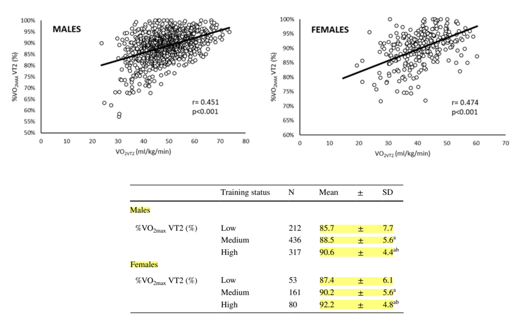

Figure & table from Benítez-Muñoz et al, 2024. Differences in the ventilatory thresholds in treadmill according to training status in 971 males and 301 females: a cross-sectional study. https://pmc.ncbi.nlm.nih.gov/articles/PMC11829848/. Showing percent VO2max at ventilatory threshold 2 (close equivalence to critical power or functional threshold power) across a range of fitness levels in runners, from 85-92%. Running threshold will tend to be slightly higher %VO2max compared to cycling threshold, hence the low-end fitness estimate is higher than typically observed in cyclists. But the high-end estimate is probably similarly bounded around 90-92%.

## Post 5

RER is a function of exercise intensity and substrate (lipid/glucose) oxidation

At threshold, RER will be ~0.85-0.95, maybe up to 1.00 by the end.

Along each GE isoline in the top figure, RER equates to a small difference of 2 %VO2max. GE drives the big differences

## Post 6

So for this specific question “is it possible to achieve an FTP of 380 W at 5.0 L/min VO2max?”

The answer is yes, with elite-level metabolic efficiency ~24% and fractional threshold ~90%VO2max

*How* to achieve that is an entirely different question which I don’t have code for (yet 😉)